# 1. Definição do Problema e Objetivo

## Pergunta de pesquisa:

- Existe uma relação entre o índice de felicidade e o PIB per capita? A relação é linear?

## Objetivo:

- Entender se o PIB per capita é um fator que influencia o índice de felicidade.
- Examinar a força e o tipo de relação (positiva, negativa, inexistente).

# 2. Coleta de Dados

#### Base de Dados: **World Happiness Reports 2013-2023**

#### Fonte: https://www.kaggle.com/datasets/joebeachcapital/world-happiness-report-2013-2023

#### Ferramentas: Jupyter Notebook, Python, Pandas.

```python
# Importa a biblioteca Pandas para análise de dados
import pandas as pd

# Importa e usa o pacote 'os' para mudar o diretório base do Python
import os
```

```python
# O diretório no qual o Python está trabalhando:
print('Diretório inicial: {}'.format(os.getcwd()))

# Muda para o diretório contendo a base de dados
os.chdir(r'C:\Users\vinic\OneDrive\Documentos\GitHub\world-happiness-reports')
print('Diretório final: {}'.format(os.getcwd()))
```

```
Diretório inicial: C:\Users\vinic\OneDrive\Documentos\GitHub\world-happiness-reports
Diretório final: C:\Users\vinic\OneDrive\Documentos\GitHub\world-happiness-reports
```

```python
# Lista os arquivos no diretório
os.listdir()
```

```
['.git',
 '.ipynb_checkpoints',
 'analise_de_dados.html',
 'analise_de_dados.ipynb',
 'README.md',
 'World Happiness Report 2013.csv',
 'World Happiness Report 2015.csv',
 'World Happiness Report 2016.csv',
 'World Happiness Report 2017.csv',
 'World Happiness Report 2018.csv',
 'World Happiness Report 2019.csv',
 'World Happiness Report 2020.csv',
 'World Happiness Report 2021.csv',
 'World Happiness Report 2022.csv',
 'World Happiness Report 2023.csv',
 'WorldHappinessIndex2013-2023.csv']
```

```python
# Lendo o arquivo CSV da base de dados e armazenando em um DataFrame
df_pib_felicidade_2023 = pd.read_csv('World Happiness Report 2023.csv', sep=',', encoding='utf8')

# Coletando apenas as colunas 'Ladder score (Índice de Felicidade)' e 'Logged GDP per capita (PIB per capita)'
df_pib_felicidade_2023 = df_pib_felicidade_2023[['Country name', 'Logged GDP per capita', 'Ladder score']]
```

```python
# Retorna as informações técnicas sobre o DataFrame
df_pib_felicidade_2023.info(memory_usage='deep')
```

```
<class 'pandas.core.frame.DataFrame'>
RangeIndex: 137 entries, 0 to 136
Data columns (total 3 columns):
 #   Column                 Non-Null Count  Dtype
---  ------                 --------------  -----
 0   Country name           137 non-null    object
 1   Logged GDP per capita  137 non-null    float64
 2   Ladder score           137 non-null    float64
dtypes: float64(2), object(1)
memory usage: 9.9 KB
```

```python
# Ordena (decrescente) pelo Índice de Felicidade e armazena os dados dos 10 maiores em um novo DataFrame
df_pib_felicidade_2023_grupo_1 = df_pib_felicidade_2023.sort_values(by='Ladder score', ascending=False).head(10)

# Exibe o DataFrame
df_pib_felicidade_2023_grupo_1
```

|  | Country name | Logged GDP per capita | Ladder score |
| --- | --- | --- | --- |
| 0 | Finland | 10.792 | 7.804 |
| 1 | Denmark | 10.962 | 7.586 |
| 2 | Iceland | 10.896 | 7.530 |
| 3 | Israel | 10.639 | 7.473 |
| 4 | Netherlands | 10.942 | 7.403 |
| 5 | Sweden | 10.883 | 7.395 |
| 6 | Norway | 11.088 | 7.315 |
| 7 | Switzerland | 11.164 | 7.240 |
| 8 | Luxembourg | 11.660 | 7.228 |
| 9 | New Zealand | 10.662 | 7.123 |

```python
# Calcula a diferença absoluta entre o Ladder score e o ponto médio entre os extremos do intervalo do índice de felicidade [1.859, 7.804]: 4.832
df_pib_felicidade_2023['diff'] = abs(df_pib_felicidade_2023['Ladder score'] - 4.832)

# Ordena os países pela diferença e seleciona os 10 mais próximos
df_pib_felicidade_2023_grupo_2 = df_pib_felicidade_2023.sort_values(by='diff').head(10)

# Ordena de forma decrescente pelo Ladder score
df_pib_felicidade_2023_grupo_2 = df_pib_felicidade_2023_grupo_2.sort_values(by='Ladder score', ascending=False)

# Remove a coluna de diferença
df_pib_felicidade_2023_grupo_2 = df_pib_felicidade_2023_grupo_2.drop(columns=['diff'])

# Exibe o DataFrame
df_pib_felicidade_2023_grupo_2
```

|  | Country name | Logged GDP per capita | Ladder score |
| --- | --- | --- | --- |
| 94 | Nigeria | 8.496 | 4.981 |
| 95 | Cameroon | 8.217 | 4.973 |
| 96 | Mozambique | 7.116 | 4.954 |
| 97 | Iraq | 9.098 | 4.941 |
| 98 | State of Palestine | 8.716 | 4.908 |
| 99 | Morocco | 8.973 | 4.903 |
| 100 | Iran | 9.610 | 4.876 |
| 101 | Senegal | 8.155 | 4.855 |
| 102 | Mauritania | 8.591 | 4.724 |
| 103 | Burkina Faso | 7.667 | 4.638 |

```python
# Remove a coluna de diferença
df_pib_felicidade_2023 = df_pib_felicidade_2023.drop(columns=['diff'])

# Ordena (decrescente) pelo Índice de Felicidade e armazena os dados dos 10 menores em um novo DataFrame
df_pib_felicidade_2023_grupo_3 = df_pib_felicidade_2023.sort_values(by='Ladder score', ascending=False).tail(10)

# Exibe o DataFrame
df_pib_felicidade_2023_grupo_3
```

|  | Country name | Logged GDP per capita | Ladder score |
| --- | --- | --- | --- |
| 127 | Zambia | 8.074 | 3.982 |
| 128 | Tanzania | 7.857 | 3.694 |
| 129 | Comoros | 8.075 | 3.545 |
| 130 | Malawi | 7.302 | 3.495 |
| 131 | Botswana | 9.629 | 3.435 |
| 132 | Congo (Kinshasa) | 7.007 | 3.207 |
| 133 | Zimbabwe | 7.641 | 3.204 |
| 134 | Sierra Leone | 7.394 | 3.138 |
| 135 | Lebanon | 9.478 | 2.392 |
| 136 | Afghanistan | 7.324 | 1.859 |

# 3. Limpeza e Preparação dos Dados

```python
# Verifica se há valores ausentes no DataFrame
valores_ausentes = df_pib_felicidade_2023.isnull().sum()
print(f"Número de valores ausentes por coluna: \n{valores_ausentes}")

# Verifica se há países duplicados no DataFrame
duplicatas = df_pib_felicidade_2023[df_pib_felicidade_2023.duplicated(subset='Country name', keep=False)]

if duplicatas.empty:
    print("\nNão há países duplicados no DataFrame.")
else:
    print(f"\nPaíses duplicados: {duplicatas}")
```

```
Número de valores ausentes por coluna:
Country name             0
Logged GDP per capita    0
Ladder score             0
dtype: int64

Não há países duplicados no DataFrame.
```

```python
# Obtém os nomes dos países de cada dataframe dos grupos 1, 2 e 3
paises_grupo_1 = set(df_pib_felicidade_2023_grupo_1['Country name'])
paises_grupo_2 = set(df_pib_felicidade_2023_grupo_2['Country name'])
paises_grupo_3 = set(df_pib_felicidade_2023_grupo_3['Country name'])

# Encontra a interseção dos três conjuntos
paises_comuns = paises_grupo_1 & paises_grupo_2 & paises_grupo_3

# Exibe os países comuns (se houver)
if paises_comuns:
	print(f"Países com nomes iguais entre os três dataframes: {paises_comuns}")
else:
	print("Não há países com nomes iguais entre os três dataframes")
```

```
Não há países com nomes iguais entre os três dataframes
```

```python
# Junta os três dataframes em um novo dataframe com os 30 países selecionados
df_pib_felicidade_2023_30_paises = pd.concat([df_pib_felicidade_2023_grupo_1, df_pib_felicidade_2023_grupo_2, df_pib_felicidade_2023_grupo_3], ignore_index=True).sort_values(by='Ladder score', ascending=False)

# Exibe o novo dataframe combinado
df_pib_felicidade_2023_30_paises
```

|  | Country name | Logged GDP per capita | Ladder score |
| --- | --- | --- | --- |
| 0 | Finland | 10.792 | 7.804 |
| 1 | Denmark | 10.962 | 7.586 |
| 2 | Iceland | 10.896 | 7.530 |
| 3 | Israel | 10.639 | 7.473 |
| 4 | Netherlands | 10.942 | 7.403 |
| 5 | Sweden | 10.883 | 7.395 |
| 6 | Norway | 11.088 | 7.315 |
| 7 | Switzerland | 11.164 | 7.240 |
| 8 | Luxembourg | 11.660 | 7.228 |
| 9 | New Zealand | 10.662 | 7.123 |
| 10 | Nigeria | 8.496 | 4.981 |
| 11 | Cameroon | 8.217 | 4.973 |
| 12 | Mozambique | 7.116 | 4.954 |
| 13 | Iraq | 9.098 | 4.941 |
| 14 | State of Palestine | 8.716 | 4.908 |
| 15 | Morocco | 8.973 | 4.903 |
| 16 | Iran | 9.610 | 4.876 |
| 17 | Senegal | 8.155 | 4.855 |
| 18 | Mauritania | 8.591 | 4.724 |
| 19 | Burkina Faso | 7.667 | 4.638 |
| 20 | Zambia | 8.074 | 3.982 |
| 21 | Tanzania | 7.857 | 3.694 |
| 22 | Comoros | 8.075 | 3.545 |
| 23 | Malawi | 7.302 | 3.495 |
| 24 | Botswana | 9.629 | 3.435 |
| 25 | Congo (Kinshasa) | 7.007 | 3.207 |
| 26 | Zimbabwe | 7.641 | 3.204 |
| 27 | Sierra Leone | 7.394 | 3.138 |
| 28 | Lebanon | 9.478 | 2.392 |
| 29 | Afghanistan | 7.324 | 1.859 |

# 4. Análise Exploratória dos Dados

## Estatísticas Descritivas - Grupo 1

```python
# Descreve e armazena uma tabela de estatísticas descritivas das colunas numéricas do DataFrame
estatisticas_grupo_1 = df_pib_felicidade_2023_grupo_1.describe()

# Seleciona apenas as colunas numéricas do DataFrame
df_pib_felicidade_2023_grupo_1_numerico = df_pib_felicidade_2023_grupo_1.select_dtypes(include=['float64'])

# Calcula o desvio padrão ao quadrado (variância) dos dados e adiciona ao DataFrame de descrição
desvio_padrao_ao_quadrado_grupo_1 = df_pib_felicidade_2023_grupo_1_numerico.std() ** 2
estatisticas_grupo_1.loc['var'] = desvio_padrao_ao_quadrado_grupo_1

# Reordena as linhas para colocar a variância antes do desvio padrão e após a média
estatisticas_grupo_1 = estatisticas_grupo_1.loc[['count', 'mean', 'var', 'std', 'min', '25%', '50%', '75%', 'max'] + [col for col in estatisticas_grupo_1.index if col not in ['count', 'mean', 'var', 'std', 'min', '25%', '50%', '75%', 'max']]]

# Exibe a tabela de estatísticas descritivas
estatisticas_grupo_1
```

|  | Logged GDP per capita | Ladder score |
| --- | --- | --- |
| count | 10.000000 | 10.000000 |
| mean | 10.968800 | 7.409700 |
| var | 0.086405 | 0.039808 |
| std | 0.293948 | 0.199519 |
| min | 10.639000 | 7.123000 |
| 25% | 10.814750 | 7.258750 |
| 50% | 10.919000 | 7.399000 |
| 75% | 11.056500 | 7.515750 |
| max | 11.660000 | 7.804000 |

## Estatísticas Descritivas - Grupo 2

```python
# Descreve e armazena uma tabela de estatísticas descritivas das colunas numéricas do DataFrame
estatisticas_grupo_2 = df_pib_felicidade_2023_grupo_2.describe()

# Seleciona apenas as colunas numéricas do DataFrame
df_pib_felicidade_2023_grupo_2_numerico = df_pib_felicidade_2023_grupo_2.select_dtypes(include=['float64'])

# Calcula o desvio padrão ao quadrado (variância) dos dados e adiciona ao DataFrame de descrição
desvio_padrao_ao_quadrado_grupo_2 = df_pib_felicidade_2023_grupo_2_numerico.std() ** 2
estatisticas_grupo_2.loc['var'] = desvio_padrao_ao_quadrado_grupo_2

# Reordena as linhas para colocar a variância antes do desvio padrão e após a média
estatisticas_grupo_2 = estatisticas_grupo_2.loc[['count', 'mean', 'var', 'std', 'min', '25%', '50%', '75%', 'max'] + [col for col in estatisticas_grupo_2.index if col not in ['count', 'mean', 'var', 'std', 'min', '25%', '50%', '75%', 'max']]]

# Exibe a tabela de estatísticas descritivas
estatisticas_grupo_2
```

|  | Logged GDP per capita | Ladder score |
| --- | --- | --- |
| count | 10.000000 | 10.000000 |
| mean | 8.463900 | 4.875300 |
| var | 0.518201 | 0.012520 |
| std | 0.719862 | 0.111893 |
| min | 7.116000 | 4.638000 |
| 25% | 8.170500 | 4.860250 |
| 50% | 8.543500 | 4.905500 |
| 75% | 8.908750 | 4.950750 |
| max | 9.610000 | 4.981000 |

## Estatísticas Descritivas - Grupo 3

```python
# Descreve e armazena uma tabela de estatísticas descritivas das colunas numéricas do DataFrame
estatisticas_grupo_3 = df_pib_felicidade_2023_grupo_3.describe()

# Seleciona apenas as colunas numéricas do DataFrame
df_pib_felicidade_2023_grupo_3_numerico = df_pib_felicidade_2023_grupo_3.select_dtypes(include=['float64'])

# Calcula o desvio padrão ao quadrado (variância) dos dados e adiciona ao DataFrame de descrição
desvio_padrao_ao_quadrado_grupo_3 = df_pib_felicidade_2023_grupo_3_numerico.std() ** 2
estatisticas_grupo_3.loc['var'] = desvio_padrao_ao_quadrado_grupo_3

# Reordena as linhas para colocar a variância antes do desvio padrão e após a média
estatisticas_grupo_3 = estatisticas_grupo_3.loc[['count', 'mean', 'var', 'std', 'min', '25%', '50%', '75%', 'max'] + [col for col in estatisticas_grupo_3.index if col not in ['count', 'mean', 'var', 'std', 'min', '25%', '50%', '75%', 'max']]]

# Exibe a tabela de estatísticas descritivas
estatisticas_grupo_3
```

|  | Logged GDP per capita | Ladder score |
| --- | --- | --- |
| count | 10.000000 | 10.00000 |
| mean | 7.978100 | 3.19510 |
| var | 0.810136 | 0.39685 |
| std | 0.900076 | 0.62996 |
| min | 7.007000 | 1.85900 |
| 25% | 7.341500 | 3.15450 |
| 50% | 7.749000 | 3.32100 |
| 75% | 8.074750 | 3.53250 |
| max | 9.629000 | 3.98200 |

## Estatísticas Descritivas - 30 Países Selecionados

```python
# Descreve e armazena uma tabela de estatísticas descritivas das colunas numéricas do DataFrame
estatisticas_30_paises = df_pib_felicidade_2023_30_paises.describe()

# Seleciona apenas as colunas numéricas do DataFrame
df_pib_felicidade_2023_30_paises_numerico = df_pib_felicidade_2023_30_paises.select_dtypes(include=['float64'])

# Calcula o desvio padrão ao quadrado (variância) dos dados e adiciona ao DataFrame de descrição
desvio_padrao_ao_quadrado_30_paises = df_pib_felicidade_2023_30_paises_numerico.std() ** 2
estatisticas_30_paises.loc['var'] = desvio_padrao_ao_quadrado_30_paises

# Reordena as linhas para colocar a variância antes do desvio padrão e após a média
estatisticas_30_paises = estatisticas_30_paises.loc[['count', 'mean', 'var', 'std', 'min', '25%', '50%', '75%', 'max'] + [col for col in estatisticas_30_paises.index if col not in ['count', 'mean', 'var', 'std', 'min', '25%', '50%', '75%', 'max']]]

# Exibe a tabela de estatísticas descritivas
estatisticas_30_paises
```

|  | Logged GDP per capita | Ladder score |
| --- | --- | --- |
| count | 30.000000 | 30.000000 |
| mean | 9.136933 | 5.160033 |
| var | 2.215473 | 3.243895 |
| std | 1.488447 | 1.801082 |
| min | 7.007000 | 1.859000 |
| 25% | 7.911250 | 3.582250 |
| 50% | 8.844500 | 4.905500 |
| 75% | 10.759500 | 7.237000 |
| max | 11.660000 | 7.804000 |

# Gráficos de Dispersão - Grupo 1

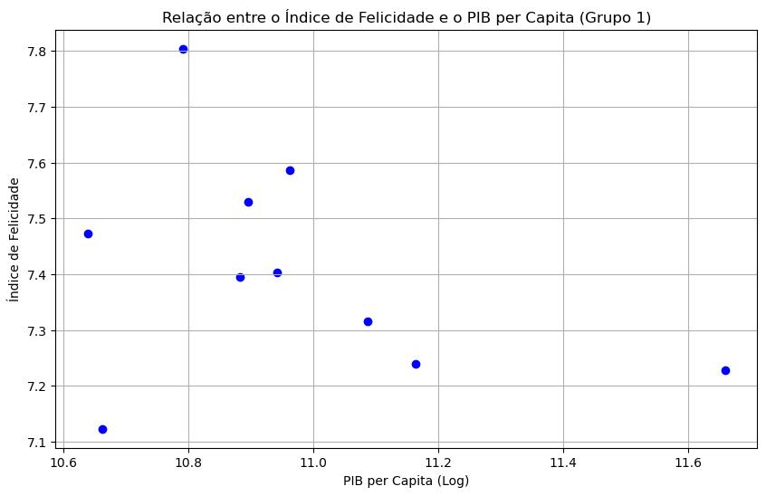

```python
import matplotlib.pyplot as plt

# Cria o gráfico de dispersão
plt.figure(figsize=(10, 6))
plt.scatter(df_pib_felicidade_2023_grupo_1['Logged GDP per capita'], df_pib_felicidade_2023_grupo_1['Ladder score'], color='blue')

# Adiciona título e rótulos aos eixos
plt.title('Relação entre o Índice de Felicidade e o PIB per Capita (Grupo 1)')
plt.xlabel('PIB per Capita (Log)')
plt.ylabel('Índice de Felicidade')

# Adiciona uma grade ao gráfico
plt.grid(True)

# Exibe o gráfico
plt.show()
```

## Boxplots - Distribuições em categorias de PIB (baixo, médio, alto) - Grupo 1

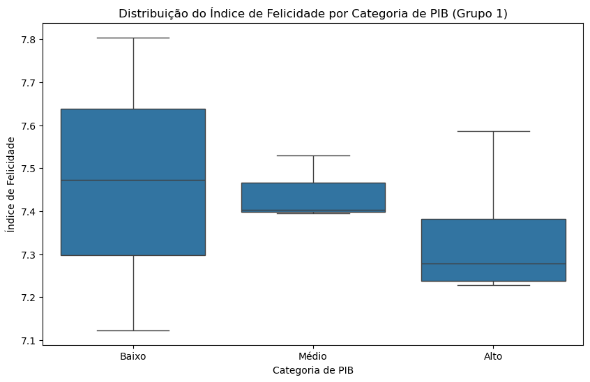

```python
# Importa a biblioteca Seaborn para visualização de dados
import seaborn as sns

# Categoriza os países do grupo 1 em três categorias de PIB (baixo, médio, alto)
quartis = df_pib_felicidade_2023_grupo_1['Logged GDP per capita'].quantile([0.33, 0.66])
df_pib_felicidade_2023_grupo_1['PIB Categoria'] = pd.cut(df_pib_felicidade_2023_grupo_1['Logged GDP per capita'], bins=[-float('inf'), quartis[0.33], quartis[0.66], float('inf')], labels=['Baixo', 'Médio', 'Alto'])

# Cria os boxplots para comparar as distribuições do Índice de Felicidade em categorias de PIB
plt.figure(figsize=(10, 6))
sns.boxplot(x='PIB Categoria', y='Ladder score', data=df_pib_felicidade_2023_grupo_1)

# Adiciona título e rótulos aos eixos
plt.title('Distribuição do Índice de Felicidade por Categoria de PIB (Grupo 1)')
plt.xlabel('Categoria de PIB')
plt.ylabel('Índice de Felicidade')

# Exibe o gráfico
plt.show()
```

# Gráficos de Dispersão - Grupo 2

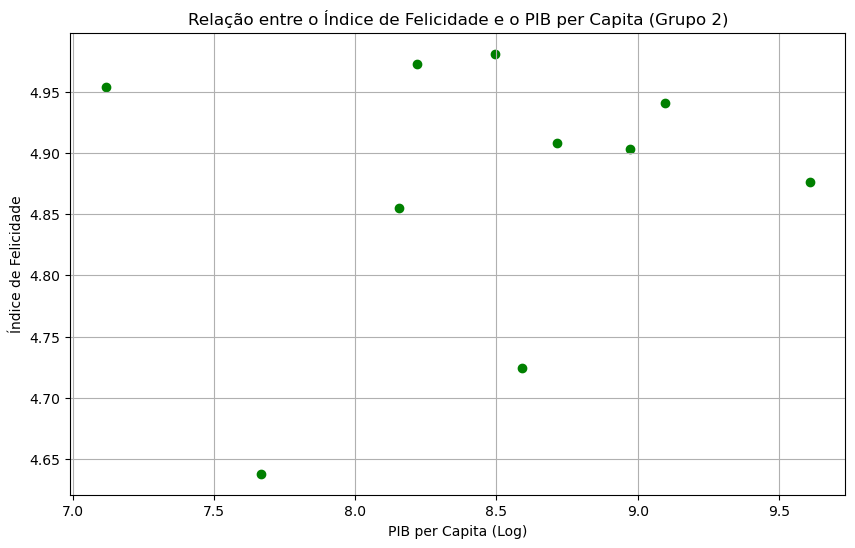

```python
# Cria o gráfico de dispersão
plt.figure(figsize=(10, 6))
plt.scatter(df_pib_felicidade_2023_grupo_2['Logged GDP per capita'], df_pib_felicidade_2023_grupo_2['Ladder score'], color='green')

# Adiciona título e rótulos aos eixos
plt.title('Relação entre o Índice de Felicidade e o PIB per Capita (Grupo 2)')
plt.xlabel('PIB per Capita (Log)')
plt.ylabel('Índice de Felicidade')

# Adiciona uma grade ao gráfico
plt.grid(True)

# Exibe o gráfico
plt.show()
```

## Boxplots - Distribuições em categorias de PIB (baixo, médio, alto) - Grupo 2

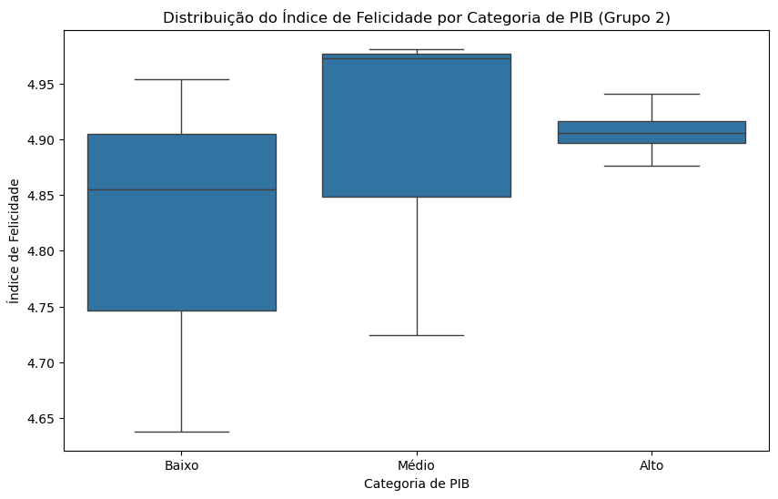

```python
# Categoriza os países do grupo 2 em três categorias de PIB (baixo, médio, alto)
quartis = df_pib_felicidade_2023_grupo_2['Logged GDP per capita'].quantile([0.33, 0.66])
df_pib_felicidade_2023_grupo_2['PIB Categoria'] = pd.cut(df_pib_felicidade_2023_grupo_2['Logged GDP per capita'], bins=[-float('inf'), quartis[0.33], quartis[0.66], float('inf')], labels=['Baixo', 'Médio', 'Alto'])

# Cria os boxplots para comparar as distribuições do Índice de Felicidade em categorias de PIB
plt.figure(figsize=(10, 6))
sns.boxplot(x='PIB Categoria', y='Ladder score', data=df_pib_felicidade_2023_grupo_2)

# Adiciona título e rótulos aos eixos
plt.title('Distribuição do Índice de Felicidade por Categoria de PIB (Grupo 2)')
plt.xlabel('Categoria de PIB')
plt.ylabel('Índice de Felicidade')

# Exibe o gráfico
plt.show()
```

# Gráficos de Dispersão - Grupo 3

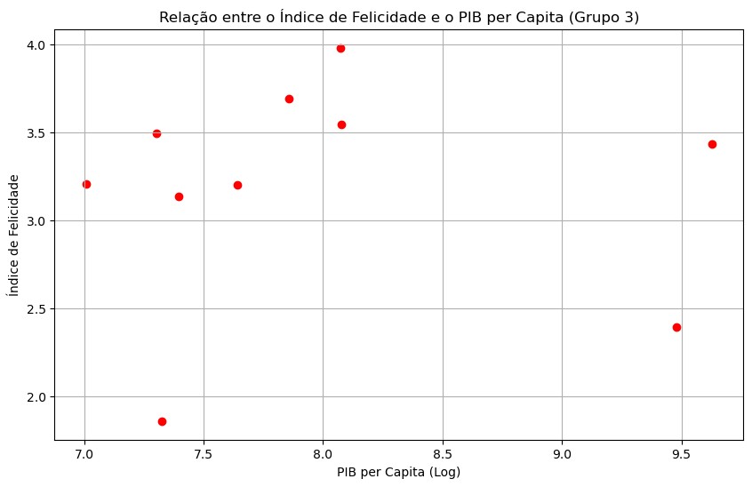

```python
# Cria o gráfico de dispersão
plt.figure(figsize=(10, 6))
plt.scatter(df_pib_felicidade_2023_grupo_3['Logged GDP per capita'], df_pib_felicidade_2023_grupo_3['Ladder score'], color='red')

# Adiciona título e rótulos aos eixos
plt.title('Relação entre o Índice de Felicidade e o PIB per Capita (Grupo 3)')
plt.xlabel('PIB per Capita (Log)')
plt.ylabel('Índice de Felicidade')

# Adiciona uma grade ao gráfico
plt.grid(True)

# Exibe o gráfico
plt.show()
```

## Boxplots - Distribuições em categorias de PIB (baixo, médio, alto) - Grupo 3

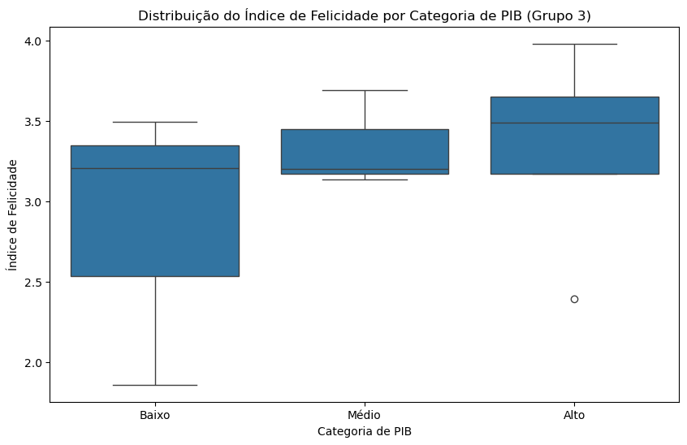

```python
# Categoriza os países do grupo 3 em três categorias de PIB (baixo, médio, alto)
quartis = df_pib_felicidade_2023_grupo_3['Logged GDP per capita'].quantile([0.33, 0.66])
df_pib_felicidade_2023_grupo_3['PIB Categoria'] = pd.cut(df_pib_felicidade_2023_grupo_3['Logged GDP per capita'], bins=[-float('inf'), quartis[0.33], quartis[0.66], float('inf')], labels=['Baixo', 'Médio', 'Alto'])

# Cria os boxplots para comparar as distribuições do Índice de Felicidade em categorias de PIB
plt.figure(figsize=(10, 6))
sns.boxplot(x='PIB Categoria', y='Ladder score', data=df_pib_felicidade_2023_grupo_3)

# Adiciona título e rótulos aos eixos
plt.title('Distribuição do Índice de Felicidade por Categoria de PIB (Grupo 3)')
plt.xlabel('Categoria de PIB')
plt.ylabel('Índice de Felicidade')

# Exibe o gráfico
plt.show()
```

## Gráficos de Dispersão - 30 Países Selecionados

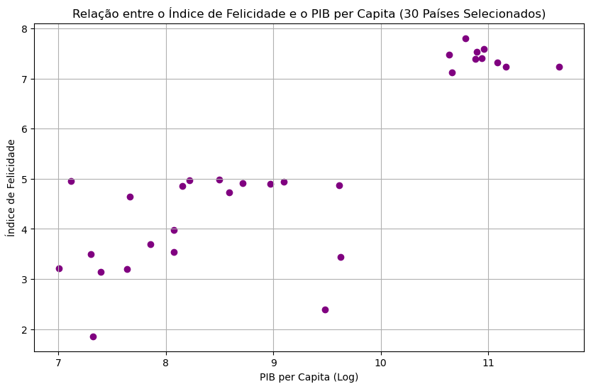

```python
# Cria o gráfico de dispersão para os 30 países selecionados
plt.figure(figsize=(10, 6))
plt.scatter(df_pib_felicidade_2023_30_paises['Logged GDP per capita'], df_pib_felicidade_2023_30_paises['Ladder score'], color='purple')

# Adiciona título e rótulos aos eixos
plt.title('Relação entre o Índice de Felicidade e o PIB per Capita (30 Países Selecionados)')
plt.xlabel('PIB per Capita (Log)')
plt.ylabel('Índice de Felicidade')

# Adiciona uma grade ao gráfico
plt.grid(True)

# Exibe o gráfico
plt.show()
```

## Boxplots - Distribuições em categorias de PIB (baixo, médio, alto) - 30 Países Selecionados

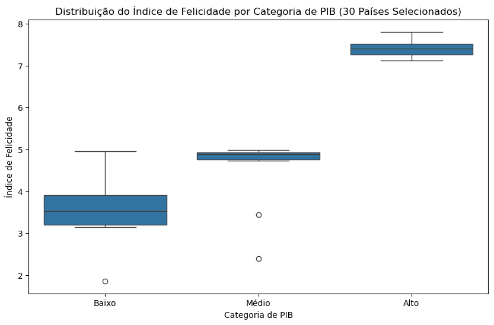

```python
# Categoriza os países dos 30 países selecionados em três categorias de PIB (baixo, médio, alto)
quartis = df_pib_felicidade_2023_30_paises['Logged GDP per capita'].quantile([0.33, 0.66])
df_pib_felicidade_2023_30_paises['PIB Categoria'] = pd.cut(df_pib_felicidade_2023_30_paises['Logged GDP per capita'], bins=[-float('inf'), quartis[0.33], quartis[0.66], float('inf')], labels=['Baixo', 'Médio', 'Alto'])

# Cria os boxplots para comparar as distribuições do Índice de Felicidade em categorias de PIB
plt.figure(figsize=(10, 6))
sns.boxplot(x='PIB Categoria', y='Ladder score', data=df_pib_felicidade_2023_30_paises)

# Adiciona título e rótulos aos eixos
plt.title('Distribuição do Índice de Felicidade por Categoria de PIB (30 Países Selecionados)')
plt.xlabel('Categoria de PIB')
plt.ylabel('Índice de Felicidade')

# Exibe o gráfico
plt.show()
```

# 5. Modelagem Estatística

## Coeficiente de Correlação de Pearson - Grupo 1

```python
# Calcula o coeficiente de correlação de Pearson para o grupo 1 usando corr()
correlacao_grupo_1_corr = df_pib_felicidade_2023_grupo_1[['Logged GDP per capita', 'Ladder score']].corr().iloc[0, 1]

# Exibe o coeficiente de correlação
print(f'Coeficiente de Correlação de Pearson para o grupo 1 (usando corr()): {correlacao_grupo_1_corr}')
```

```
Coeficiente de Correlação de Pearson para o grupo 1 (usando corr()): -0.3431938262906834
```

## Coeficiente de Correlação de Pearson - Grupo 2

```python
# Calcula o coeficiente de correlação de Pearson para o grupo 2 usando corr()
correlacao_grupo_2_corr = df_pib_felicidade_2023_grupo_2[['Logged GDP per capita', 'Ladder score']].corr().iloc[0, 1]

# Exibe o coeficiente de correlação
print(f'Coeficiente de Correlação de Pearson para o grupo 2: {correlacao_grupo_2_corr}')
```

```
Coeficiente de Correlação de Pearson para o grupo 2: 0.1574563056690951
```

## Coeficiente de Correlação de Pearson - Grupo 3

```python
# Calcula o coeficiente de correlação de Pearson para o grupo 3 usando corr()
correlacao_grupo_3_corr = df_pib_felicidade_2023_grupo_3[['Logged GDP per capita', 'Ladder score']].corr().iloc[0, 1]

# Exibe o coeficiente de correlação
print(f'Coeficiente de Correlação de Pearson para o grupo 3: {correlacao_grupo_3_corr}')
```

```
Coeficiente de Correlação de Pearson para o grupo 3: -0.013636811370425847
```

## Coeficiente de Correlação de Pearson - 30 Países Selecionados

```python
# Calcula o coeficiente de correlação de Pearson para os 30 países selecionados usando corr()
correlacao_30_paises_corr = df_pib_felicidade_2023_30_paises[['Logged GDP per capita', 'Ladder score']].corr().iloc[0, 1]

# Exibe o coeficiente de correlação
print(f'Coeficiente de Correlação de Pearson para os 30 países selecionados: {correlacao_30_paises_corr}')
```

```
Coeficiente de Correlação de Pearson para os 30 países selecionados: 0.8458695948199685
```

## Regressão Linear - Grupo 1

```
Intercepto (β0) para o grupo 1: 9.964833883882624
Coeficiente (β1) para o grupo 1: -0.23294561701212765
```

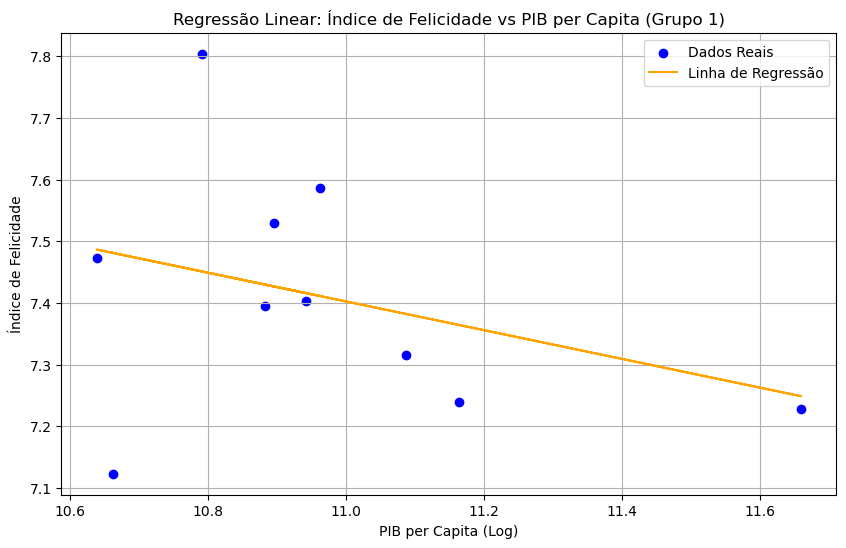

```python
# Importa a classe LinearRegression do sklearn
from sklearn.linear_model import LinearRegression

# Define as variáveis preditoras (X) e de resposta (y) para o grupo 1
X_grupo_1 = df_pib_felicidade_2023_grupo_1[['Logged GDP per capita']].values.reshape(-1, 1)
y_grupo_1 = df_pib_felicidade_2023_grupo_1['Ladder score'].values

# Cria e ajusta o modelo de regressão linear para o grupo 1
model_grupo_1 = LinearRegression()
model_grupo_1.fit(X_grupo_1, y_grupo_1)

# Obtém os coeficientes para o grupo 1
beta_0_grupo_1 = model_grupo_1.intercept_
beta_1_grupo_1 = model_grupo_1.coef_[0]

# Exibe os coeficientes
print(f'Intercepto (β0) para o grupo 1: {beta_0_grupo_1}')
print(f'Coeficiente (β1) para o grupo 1: {beta_1_grupo_1}')

# Prediz a felicidade com base no modelo para o grupo 1
y_pred_grupo_1 = model_grupo_1.predict(X_grupo_1)

# Plota a linha de regressão para o grupo 1
plt.figure(figsize=(10, 6))
plt.scatter(X_grupo_1, y_grupo_1, color='blue', label='Dados Reais')
plt.plot(X_grupo_1, y_pred_grupo_1, color='orange', label='Linha de Regressão')
plt.title('Regressão Linear: Índice de Felicidade vs PIB per Capita (Grupo 1)')
plt.xlabel('PIB per Capita (Log)')
plt.ylabel('Índice de Felicidade')
plt.legend()
plt.grid(True)
plt.show()
```

## R²: Quanto do índice de felicidade é explicado pelo PIB - Grupo 1

```python
# Calcula o coeficiente de determinação R^2 para o grupo 1
r2_grupo_1 = model_grupo_1.score(X_grupo_1, y_grupo_1)
print(f'Coeficiente de Determinação (R^2) para o grupo 1: {r2_grupo_1}')
```

```
Coeficiente de Determinação (R^2) para o grupo 1: 0.11778200240403802
```

## Regressão Linear - Grupo 2

```
Intercepto (β0) para o grupo 2: 4.668150622122941
Coeficiente (β1) para o grupo 2: 0.024474459513588308
```

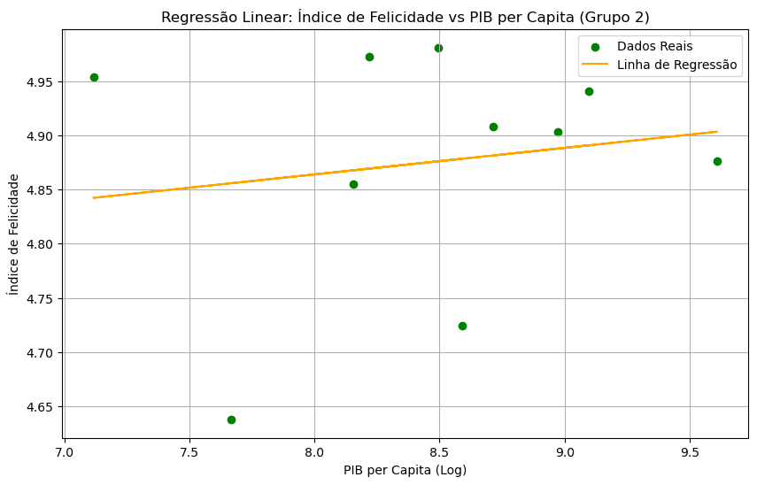

```python
# Define as variáveis preditoras (X) e de resposta (y) para o grupo 2
X_grupo_2 = df_pib_felicidade_2023_grupo_2[['Logged GDP per capita']].values.reshape(-1, 1)
y_grupo_2 = df_pib_felicidade_2023_grupo_2['Ladder score'].values

# Cria e ajusta o modelo de regressão linear para o grupo 2
model_grupo_2 = LinearRegression()
model_grupo_2.fit(X_grupo_2, y_grupo_2)

# Obtém os coeficientes para o grupo 2
beta_0_grupo_2 = model_grupo_2.intercept_
beta_1_grupo_2 = model_grupo_2.coef_[0]

# Exibe os coeficientes
print(f'Intercepto (β0) para o grupo 2: {beta_0_grupo_2}')
print(f'Coeficiente (β1) para o grupo 2: {beta_1_grupo_2}')

# Prediz a felicidade com base no modelo para o grupo 2
y_pred_grupo_2 = model_grupo_2.predict(X_grupo_2)

# Plota a linha de regressão para o grupo 2
plt.figure(figsize=(10, 6))
plt.scatter(X_grupo_2, y_grupo_2, color='green', label='Dados Reais')
plt.plot(X_grupo_2, y_pred_grupo_2, color='orange', label='Linha de Regressão')
plt.title('Regressão Linear: Índice de Felicidade vs PIB per Capita (Grupo 2)')
plt.xlabel('PIB per Capita (Log)')
plt.ylabel('Índice de Felicidade')
plt.legend()
plt.grid(True)
plt.show()
```

## R²: Quanto do índice de felicidade é explicado pelo PIB - Grupo 2

```python
# Calcula o coeficiente de determinação R^2 para o grupo 2
r2_grupo_2 = model_grupo_2.score(X_grupo_2, y_grupo_2)
print(f'Coeficiente de Determinação (R^2) para o grupo 2: {r2_grupo_2}')
```

```
Coeficiente de Determinação (R^2) para o grupo 2: 0.02479248819496127
```

## Regressão Linear - Grupo 3

```
Intercepto (β0) para o grupo 3: 3.2712458855575828
Coeficiente (β1) para o grupo 3: -0.00954436338947651
```

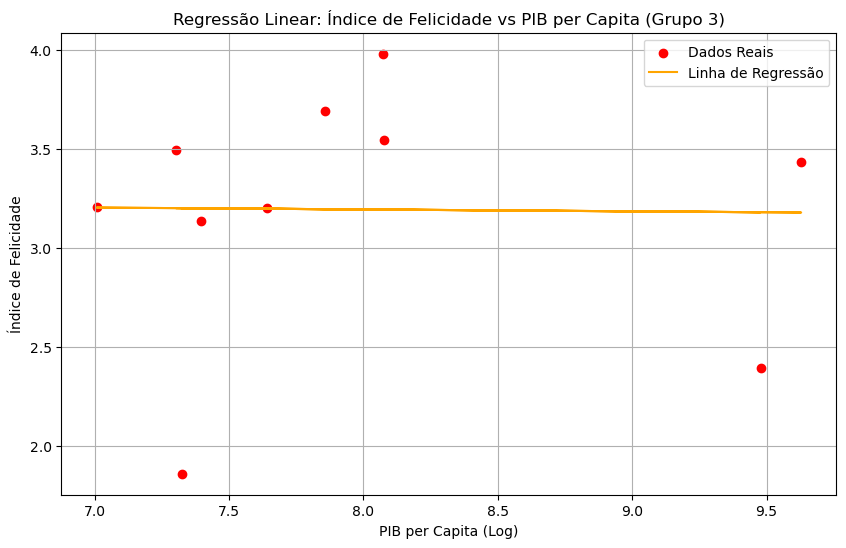

```python
# Define as variáveis preditoras (X) e de resposta (y) para o grupo 3
X_grupo_3 = df_pib_felicidade_2023_grupo_3[['Logged GDP per capita']].values.reshape(-1, 1)
y_grupo_3 = df_pib_felicidade_2023_grupo_3['Ladder score'].values

# Cria e ajusta o modelo de regressão linear para o grupo 3
model_grupo_3 = LinearRegression()
model_grupo_3.fit(X_grupo_3, y_grupo_3)

# Obtém os coeficientes para o grupo 3
beta_0_grupo_3 = model_grupo_3.intercept_
beta_1_grupo_3 = model_grupo_3.coef_[0]

# Exibe os coeficientes
print(f'Intercepto (β0) para o grupo 3: {beta_0_grupo_3}')
print(f'Coeficiente (β1) para o grupo 3: {beta_1_grupo_3}')

# Prediz a felicidade com base no modelo para o grupo 3
y_pred_grupo_3 = model_grupo_3.predict(X_grupo_3)

# Plota a linha de regressão para o grupo 3
plt.figure(figsize=(10, 6))
plt.scatter(X_grupo_3, y_grupo_3, color='red', label='Dados Reais')
plt.plot(X_grupo_3, y_pred_grupo_3, color='orange', label='Linha de Regressão')
plt.title('Regressão Linear: Índice de Felicidade vs PIB per Capita (Grupo 3)')
plt.xlabel('PIB per Capita (Log)')
plt.ylabel('Índice de Felicidade')
plt.legend()
plt.grid(True)
plt.show()
```

## R²: Quanto do índice de felicidade é explicado pelo PIB - Grupo 3

```python
# Calcula o coeficiente de determinação R^2 para o grupo 3
r2_grupo_3 = model_grupo_3.score(X_grupo_3, y_grupo_3)
print(f'Coeficiente de Determinação (R^2) para o grupo 3: {r2_grupo_3}')
```

```
Coeficiente de Determinação (R^2) para o grupo 3: 0.00018596262435277566
```

## Regressão Linear - 30 Países Selecionados

```
Intercepto (β0) para os 30 países selecionados: -4.191956417866728
Coeficiente (β1) para os 30 países selecionados: 1.0235370457483979
```

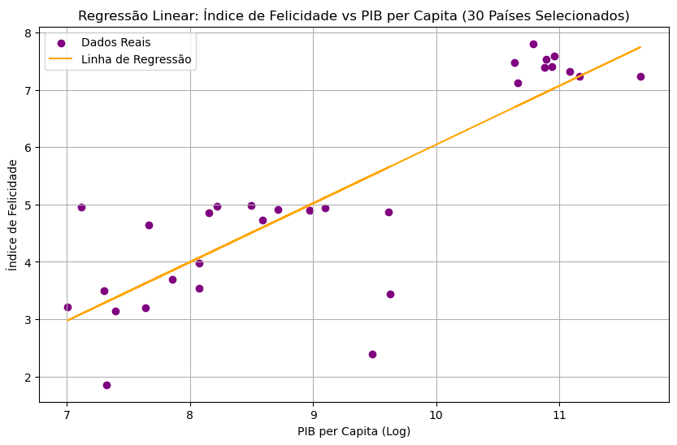

```python
# Define as variáveis preditoras (X) e de resposta (y) para os 30 países selecionados
X_30_paises = df_pib_felicidade_2023_30_paises[['Logged GDP per capita']].values.reshape(-1, 1)
y_30_paises = df_pib_felicidade_2023_30_paises['Ladder score'].values

# Cria e ajusta o modelo de regressão linear para os 30 países selecionados
model_30_paises = LinearRegression()
model_30_paises.fit(X_30_paises, y_30_paises)

# Obtém os coeficientes para os 30 países selecionados
beta_0_30_paises = model_30_paises.intercept_
beta_1_30_paises = model_30_paises.coef_[0]

# Exibe os coeficientes
print(f'Intercepto (β0) para os 30 países selecionados: {beta_0_30_paises}')
print(f'Coeficiente (β1) para os 30 países selecionados: {beta_1_30_paises}')

# Prediz a felicidade com base no modelo para os 30 países selecionados
y_pred_30_paises = model_30_paises.predict(X_30_paises)

# Plota a linha de regressão para os 30 países selecionados
plt.figure(figsize=(10, 6))
plt.scatter(X_30_paises, y_30_paises, color='purple', label='Dados Reais')
plt.plot(X_30_paises, y_pred_30_paises, color='orange', label='Linha de Regressão')
plt.title('Regressão Linear: Índice de Felicidade vs PIB per Capita (30 Países Selecionados)')
plt.xlabel('PIB per Capita (Log)')
plt.ylabel('Índice de Felicidade')
plt.legend()
plt.grid(True)
plt.show()
```

## R²: Quanto do índice de felicidade é explicado pelo PIB - 30 Países Selecionados

```python
# Calcula o coeficiente de determinação R^2 para os 30 países selecionados
r2_30_paises = model_30_paises.score(X_30_paises, y_30_paises)
print(f'Coeficiente de Determinação (R^2) para os 30 países selecionados: {r2_30_paises}')
```

```
Coeficiente de Determinação (R^2) para os 30 países selecionados: 0.7154953714408974
```

# 6. Interpretação dos Resultados

## Conclusões das Correlações

### Grupo 1

A correlação de Pearson para o Grupo 1 é de -0.343. Isso indica uma correlação negativa moderada entre o PIB per capita e o índice de felicidade. Em outras palavras, à medida que o PIB per capita aumenta, o índice de felicidade tende a diminuir ligeiramente para este grupo.

### Grupo 2

A correlação de Pearson para o Grupo 2 é de 0.157. Isso sugere uma correlação positiva fraca entre o PIB per capita e o índice de felicidade. Portanto, um aumento no PIB per capita está associado a um pequeno aumento no índice de felicidade para este grupo.

### Grupo 3

A correlação de Pearson para o Grupo 3 é de -0.014. Isso indica uma correlação praticamente inexistente entre o PIB per capita e o índice de felicidade. Assim, para este grupo, o PIB per capita não parece ter uma relação significativa com o índice de felicidade.

### 30 Países Selecionados

A correlação de Pearson para os 30 países selecionados é de 0.846. Isso indica uma forte correlação positiva entre o PIB per capita e o índice de felicidade. Portanto, um aumento no PIB per capita está fortemente associado a um aumento no índice de felicidade para este conjunto de países.

## Conclusões dos Coeficientes de Regressão Linear (𝛽1)

### Grupo 1

O coeficiente 𝛽1 para o Grupo 1 é de aproximadamente -0.233. Isso indica que, para cada aumento unitário no PIB per capita (logaritmo), o índice de felicidade diminui em 0.233 pontos. Essa relação negativa sugere que, dentro deste grupo, um maior PIB per capita está associado a uma leve diminuição no índice de felicidade.

### Grupo 2

O coeficiente 𝛽1 para o Grupo 2 é de aproximadamente 0.024. Isso sugere que, para cada aumento unitário no PIB per capita (logaritmo), o índice de felicidade aumenta em 0.024 pontos. No entanto, esse aumento é muito pequeno, indicando uma relação fraca entre o PIB per capita e o índice de felicidade para este grupo.

### Grupo 3

O coeficiente 𝛽1 para o Grupo 3 é de aproximadamente -0.010. Isso indica que, para cada aumento unitário no PIB per capita (logaritmo), o índice de felicidade diminui em 0.010 pontos. Essa relação é praticamente inexistente, sugerindo que o PIB per capita não tem um impacto significativo no índice de felicidade para este grupo.

### 30 Países Selecionados

O coeficiente 𝛽1 para os 30 países selecionados é de aproximadamente 1.024. Isso indica que, para cada aumento unitário no PIB per capita (logaritmo), o índice de felicidade aumenta em 1.024 pontos. Essa relação positiva e significativa sugere que, para este conjunto de países, um maior PIB per capita está fortemente associado a um aumento no índice de felicidade.

## Conclusões dos Coeficientes de Determinação (R²)

### Grupo 1

O coeficiente de determinação (R²) para o Grupo 1 é de aproximadamente 0.118. Isso indica que cerca de 11.8% da variação no índice de felicidade pode ser explicada pelo PIB per capita para este grupo. Embora haja alguma relação, a maior parte da variação no índice de felicidade é explicada por outros fatores não incluídos no modelo.

### Grupo 2

O coeficiente de determinação (R²) para o Grupo 2 é de aproximadamente 0.025. Isso sugere que apenas 2.5% da variação no índice de felicidade pode ser explicada pelo PIB per capita para este grupo. A relação entre o PIB per capita e o índice de felicidade é muito fraca, indicando que outros fatores têm um papel muito mais significativo na determinação da felicidade.

### Grupo 3

O coeficiente de determinação (R²) para o Grupo 3 é de aproximadamente 0.0002. Isso indica que praticamente nenhuma variação no índice de felicidade pode ser explicada pelo PIB per capita para este grupo. O PIB per capita não é um fator relevante para explicar a felicidade neste grupo de países.

### 30 Países Selecionados

O coeficiente de determinação (R²) para os 30 países selecionados é de aproximadamente 0.715. Isso indica que cerca de 71.5% da variação no índice de felicidade pode ser explicada pelo PIB per capita para este conjunto de países. Há uma forte relação entre o PIB per capita e o índice de felicidade, sugerindo que o PIB per capita é um fator importante na determinação da felicidade para esses países.

# 7. Resumo dos Resultados

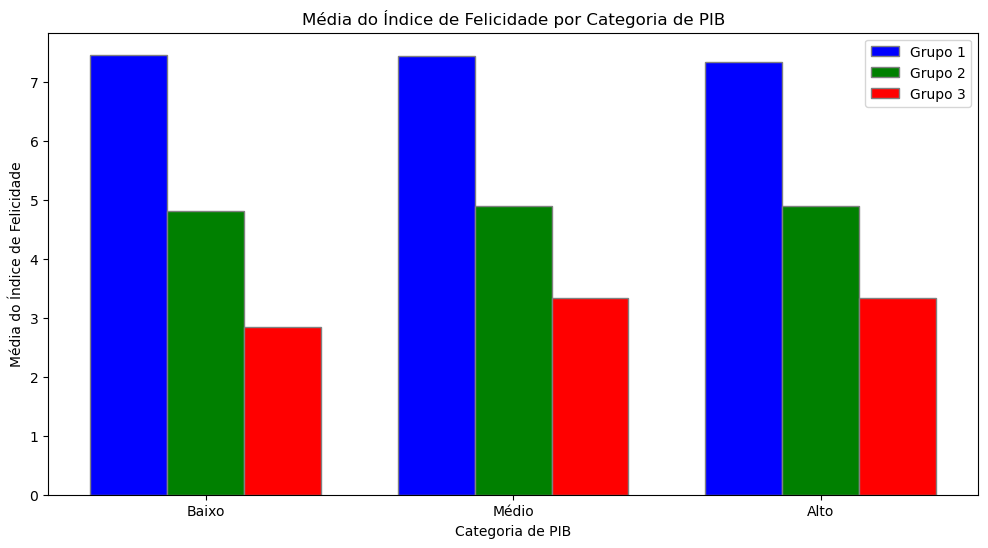

```python
# Calcula a média do índice de felicidade para cada categoria de PIB nos três grupos
media_felicidade_grupo_1 = df_pib_felicidade_2023_grupo_1.groupby('PIB Categoria', observed=True)['Ladder score'].mean()
media_felicidade_grupo_2 = df_pib_felicidade_2023_grupo_2.groupby('PIB Categoria', observed=True)['Ladder score'].mean()
media_felicidade_grupo_3 = df_pib_felicidade_2023_grupo_3.groupby('PIB Categoria', observed=True)['Ladder score'].mean()

# Cria um DataFrame com as médias para facilitar a plotagem
media_felicidade = pd.DataFrame({
    'Grupo 1': media_felicidade_grupo_1,
    'Grupo 2': media_felicidade_grupo_2,
    'Grupo 3': media_felicidade_grupo_3
}).reset_index()

# Define a largura das barras
bar_width = 0.25

# Define a posição das barras no eixo x
r1 = range(len(media_felicidade))
r2 = [x + bar_width for x in r1]
r3 = [x + bar_width for x in r2]

# Cria o gráfico de barras
plt.figure(figsize=(12, 6))
plt.bar(r1, media_felicidade['Grupo 1'], color='blue', width=bar_width, edgecolor='grey', label='Grupo 1')
plt.bar(r2, media_felicidade['Grupo 2'], color='green', width=bar_width, edgecolor='grey', label='Grupo 2')
plt.bar(r3, media_felicidade['Grupo 3'], color='red', width=bar_width, edgecolor='grey', label='Grupo 3')

# Adiciona título e rótulos aos eixos
plt.title('Média do Índice de Felicidade por Categoria de PIB')
plt.xlabel('Categoria de PIB')
plt.ylabel('Média do Índice de Felicidade')
plt.xticks([r + bar_width for r in range(len(media_felicidade))], media_felicidade['PIB Categoria'])

# Adiciona uma legenda
plt.legend()

# Exibe o gráfico
plt.show()
```

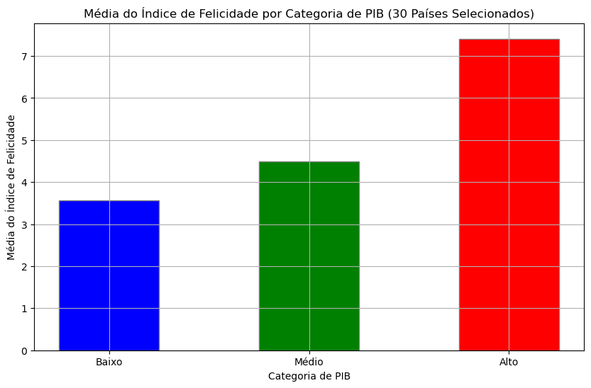

```python
# Calcula a média do índice de felicidade para cada categoria de PIB nos 30 países selecionados
media_felicidade_30_paises = df_pib_felicidade_2023_30_paises.groupby('PIB Categoria', observed=True)['Ladder score'].mean()

# Cria um DataFrame com as médias para facilitar a plotagem
media_felicidade_30_paises_df = pd.DataFrame({
    'PIB Categoria': media_felicidade_30_paises.index,
    'Média do Índice de Felicidade': media_felicidade_30_paises.values
}).reset_index(drop=True)

# Define a largura das barras
bar_width = 0.5

# Cria o gráfico de barras
plt.figure(figsize=(10, 6))
plt.bar(media_felicidade_30_paises_df['PIB Categoria'], media_felicidade_30_paises_df['Média do Índice de Felicidade'], color=['blue', 'green', 'red'], width=bar_width, edgecolor='grey')

# Adiciona título e rótulos aos eixos
plt.title('Média do Índice de Felicidade por Categoria de PIB (30 Países Selecionados)')
plt.xlabel('Categoria de PIB')
plt.ylabel('Média do Índice de Felicidade')

# Adiciona uma grade ao gráfico
plt.grid(True)

# Exibe o gráfico
plt.show()
```

### Correlações

- **Grupo 1**: A correlação de Pearson é de -0.343, indicando uma correlação negativa moderada entre o PIB per capita e o índice de felicidade. À medida que o PIB per capita aumenta, o índice de felicidade tende a diminuir ligeiramente.
- **Grupo 2**: A correlação de Pearson é de 0.157, sugerindo uma correlação positiva fraca entre o PIB per capita e o índice de felicidade. Um aumento no PIB per capita está associado a um pequeno aumento no índice de felicidade.
- **Grupo 3**: A correlação de Pearson é de -0.014, indicando uma correlação praticamente inexistente entre o PIB per capita e o índice de felicidade. O PIB per capita não parece ter uma relação significativa com o índice de felicidade.
- **30 Países Selecionados**: A correlação de Pearson é de 0.846, indicando uma forte correlação positiva entre o PIB per capita e o índice de felicidade. Um aumento no PIB per capita está fortemente associado a um aumento no índice de felicidade.

### Coeficientes de Regressão Linear (𝛽1)

- **Grupo 1**: O coeficiente 𝛽1 é de aproximadamente -0.233, sugerindo que um maior PIB per capita está associado a uma leve diminuição no índice de felicidade.
- **Grupo 2**: O coeficiente 𝛽1 é de aproximadamente 0.024, indicando uma relação fraca entre o PIB per capita e o índice de felicidade.
- **Grupo 3**: O coeficiente 𝛽1 é de aproximadamente -0.010, sugerindo que o PIB per capita não tem um impacto significativo no índice de felicidade.
- **30 Países Selecionados**: O coeficiente 𝛽1 é de aproximadamente 1.024, indicando que um maior PIB per capita está fortemente associado a um aumento no índice de felicidade.

### Coeficientes de Determinação (R²)

- **Grupo 1**: O coeficiente de determinação (R²) é de aproximadamente 0.118, indicando que cerca de 11.8% da variação no índice de felicidade pode ser explicada pelo PIB per capita.
- **Grupo 2**: O coeficiente de determinação (R²) é de aproximadamente 0.025, sugerindo que apenas 2.5% da variação no índice de felicidade pode ser explicada pelo PIB per capita.
- **Grupo 3**: O coeficiente de determinação (R²) é de aproximadamente 0.0002, indicando que praticamente nenhuma variação no índice de felicidade pode ser explicada pelo PIB per capita.
- **30 Países Selecionados**: O coeficiente de determinação (R²) é de aproximadamente 0.715, indicando que cerca de 71.5% da variação no índice de felicidade pode ser explicada pelo PIB per capita.

## Limitações

- **Fatores Adicionais**: A felicidade pode depender de muitos outros fatores além do PIB per capita, como desigualdade de renda, educação, saúde, segurança, cultura, entre outros.
- **Dados Limitados**: A análise foi baseada em dados de um único ano. Resultados mais robustos poderiam ser obtidos com dados de múltiplos anos.
- **Grupos Pequenos**: A divisão dos países em três grupos pode ter limitado a capacidade de detectar relações mais sutis entre o PIB per capita e a felicidade.
- **Relações Não Lineares**: A análise considerou apenas relações lineares. Relações não lineares entre o PIB per capita e a felicidade podem existir e não foram exploradas.

# 8. Próximos Passos

- Usar dados de outros anos para verificar se os resultados são consistentes.
- Considerar variáveis adicionais: desigualdade de renda, educação, saúde e etc.
- Aprofundar análises: Estudos comparativos regionais.